# Predicción del precio de los jugadores en las 5 ligas de futbol europeas mas importantes

Enfoque Estadístico del Aprendizaje

Rodrigo Marques, Agustín Cepeda, Germán Fernández

15 de Diciembre de 2024

```r
#Librerias
library(tidyverse)
library(tidymodels)
library(GGally)
library(ggplot2)
library(MASS)
library(robustbase)
library(dplyr)
library(corrplot)
library(caret)
library(viridis)
library(gridExtra)
library(kableExtra)
```

# Objetivo

Por este motivo, y haciendo uso de los conocimientos aportados por la materia, optamos por profundizar en el desarrollo de métodos de regresión robustos para hacer análisis predictivos, haciendo foco en la explicabilidad del modelo para predecir las transferencias de los jugadores.

El objetivo del presente trabajo consiste en la utilización distintos métodos robustos para predecir la variable objetivo: el precio de transferencia de los jugadores.

# Introducción

En el método lineal clásico se utiliza el método de cuadrados mínimos para encontrar los parámetros $\beta$.

La función de pérdida que se quiere minimizar es la suma del cuadrado de los residuos.

$$g(a, b) = \sum_{i=1}^n \left( Y_i - \left( a + b X_i \right) \right)^2$$

En los modelos lineales robustos queremos cambiar la función de perdida tal que:

- Sea Insensible a valores extremadamente grandes o outliers(o residuos grandes)
- Crezca menos que mínimos cuadrados cuando miramos lo suficientemente lejos del cero
- Tenga Alta eficiencia: si los datos de la muestra siguieran el modelo de regresión con errores normales, queremos que el estimador (beta) que el método robusta calcula se parezca al de mínimos cuadrados, por lo que la función de pérdida que el método robusto calcula debería parecerse al de mínimos cuadrado.

$$g(a, b) = \sum_{i=1}^n \rho \left( \frac{Y_i - \left( a + b X_i
\right)}{s_n} \right)$$

donde $\rho$ : R →R es una función acotada, creciente y simétrica alrededor del cero, y $s_n$ es un estimador de escala que juega el papel de σ en el modelo clásico de regresión.

Una posibilidad es ajustar una recta usando un procedimiento de ajuste robusto, por ejemplo un MM-estimador de regresión, propuesto por Yohai [1987]. En R, esto está programado dentro de la rutina lmrob en el paquete robustbase de R. La estimación se hace en tres etapas, se propone un estimador inicial de los parámetros, a partir de él se estima a sn y nalmente se obtienen los estimadores de los parámetros a partir de ellos, minimizando la función objetivo

Existen varias funciones $\rho$ que serán evaluadas en el presente trabajo. Por defecto, robustbase utiliza la bicuadrada (bisquare), pero también se pueden implementar lqq, welsh, optimal, etc.

Las funciones $\rho$ más comunes son:

1. Bisquare (Tukey):
   $$\rho(x) = \begin{cases}
   1 - (1 - (x/k)^2)^3 & \text{si } |x| \leq k \\
   1 & \text{si } |x| > k
   \end{cases}$$
2. Huber:
   $$\rho(x) = \begin{cases}
   \frac{x^2}{2} & \text{si } |x| \leq k \\
   k|x| - \frac{k^2}{2} & \text{si } |x| > k
   \end{cases}$$
3. Welsh:
   $$\rho(x) = 1 - \exp(-x^2/k^2)$$
4. Hampel:
   $$\rho(x) = \begin{cases}
   \frac{x^2}{2} & \text{si } |x| \leq a \\
   a|x| - \frac{a^2}{2} & \text{si } a < |x| \leq b \\
   \frac{a(c|x| - x^2/2 - bc + b^2/2)}{c-b} & \text{si } b < |x|
   \leq c \\
   a(c - \frac{b}{2}) & \text{si } |x| > c
   \end{cases}$$
5. LQQ (Linearly Quadratically Quadratic):
   $$\rho(x) = \begin{cases}
   \frac{x^2}{2} & \text{si } |x| \leq c_1 \\
   c_1|x| - \frac{c_1^2}{2} & \text{si } c_1 < |x| \leq c_2 \\
   \frac{(c_3|x| - x^2/2)}{c_3-c_2} & \text{si } c_2 < |x| \leq c_3
   \\
   c_3 & \text{si } |x| > c_3
   \end{cases}$$

Donde $k$, $a$, $b$, $c$, $c_1$, $c_2$ y $c_3$ son constantes que determinan los puntos de quiebre y la forma de cada función.

Existen muchas otras propuestas de estimadores robustos para regresión, por ejemplo LMS (least median of squares), LTS (least trimmed squares), τ−estimadores de regresión, y casi todas están implementadas en R.

# Dataset

El set de datos consiste en dos bases, ambas obtenidas de Kaggle.

La base de datos con los precios de los jugadores se obtuvo de la web Transfermarkt. Cuenta con 32405 registros, y dos de sus variables son los precios actuales de los jugadores y el precio mas alta alcanzado. Además cuenta con la información del club y liga actual de cada jugador.

Las otra base de datos cuenta con las métricas durante la temporada 2023/2023 de los jugadores de las 5 ligas mas importantes del fútbol europeo. Algunas de sus variables son Edad, goles anotados, asistencias, posición dentro del campo de juego, nacionalidad, entre otras.

Ambas bases de datos se unieron por el nombre y apellido del jugador, y el club actual. Adicionalmente, se agregó la variable Continente al dataset final, la cual informa el continente natal de cada jugador.

El dataset se divide en Entrenamiento y Prueba, de manera estratificada según el precio. Se utiliza el siguiente boxplot para generar una nueva categoría que categorice según el precio del jugador.

Luego utilizaremos esta nueva variable para realizar la división del dataset de manera estratificada.

## Categorías de la nueva variable

El objetivo es que quedan estratificados los jugadores mas caros u outliers, por eso no se realiza una división por debajo de Q2.

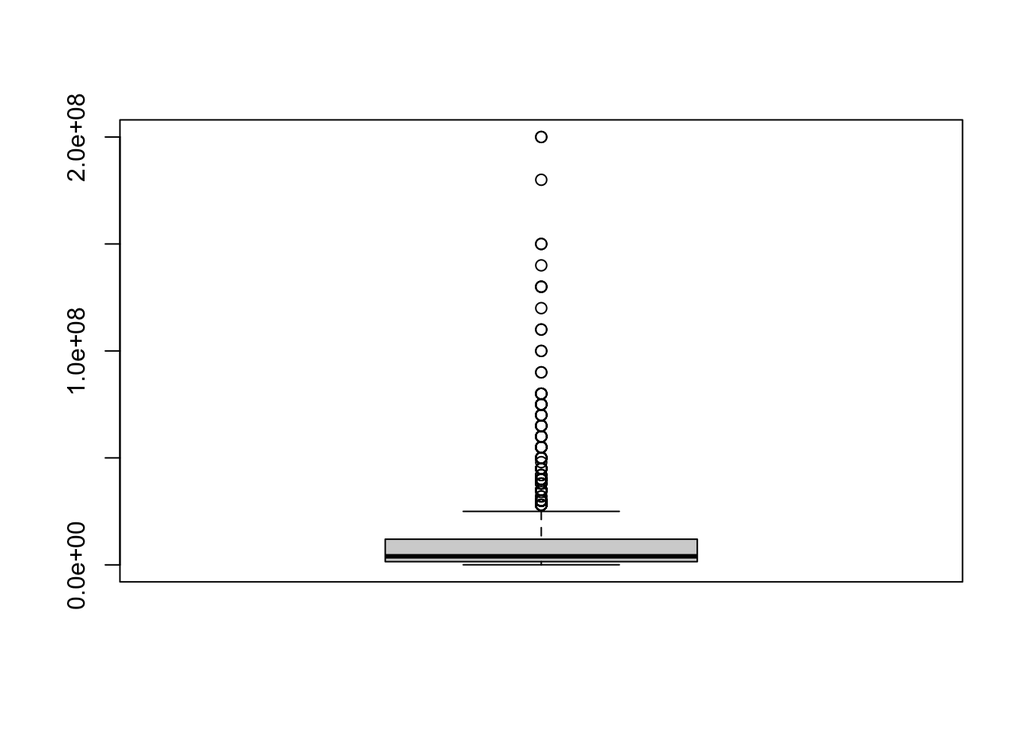

```r
# Carga de datset
df <- as.data.frame(read.csv("dataset.csv"))
df <- as.data.frame(df)
df <- na.omit(df)
colnames(df)[colnames(df) == "market_value_in_eur"] <- "precio"

# Agregar nueva variable que tenga en cuenta los precios de los jugadores y poder hacer un split
# test-train estratificado
caja_precios <- boxplot(df$precio)
```

```r
caja_precios$stats
```

```
##         [,1]
## [1,] 5.0e+04
## [2,] 1.5e+06
## [3,] 4.0e+06
## [4,] 1.2e+07
## [5,] 2.5e+07
```

```r
df$precio_cat <- NA

for (i in 1:length(df$precio)) {
  if (df$precio[i] >= 100000000) {
    df$precio_cat[i] <- "muy_alto"}
  if (df$precio[i] < 100000000 && df$precio[i] >= caja_precios$stats[5]) {
    df$precio_cat[i] <- "alto"}
  if (df$precio[i] < caja_precios$stats[5] && df$precio[i] >= caja_precios$stats[4]) {
    df$precio_cat[i] <- "medio"}
  if (df$precio[i] < caja_precios$stats[4] && df$precio[i] >= caja_precios$stats[3]) {
    df$precio_cat[i] <- "bajo"}
  if (df$precio[i] < caja_precios$stats[3]){
    df$precio_cat[i] <- "muy_bajo"}
}

# Suponiendo que `df$clase` es la variable categórica
set.seed(28749658)  # Fijar semilla para reproducibilidad

# Crear índices estratificados basados en la variable `clase`
train_indices <- createDataPartition(df$precio_cat, p = 0.7, list = FALSE)  # 70% entrenamiento

# Dividir los datos
train_data <- df[train_indices, ]
test_data <- df[-train_indices, ]

# Verificar la distribución de clases
table(train_data$precio_cat)
```

```
##
##     alto     bajo    medio muy_alto muy_bajo
##      132      298      171       10      546
```

```r
table(test_data$precio_cat)
```

```
##
##     alto     bajo    medio muy_alto muy_bajo
##       56      127       73        4      234
```

# Análisis Exploratorio de Datos

## Gráficos de barras de algunas variables categóricas

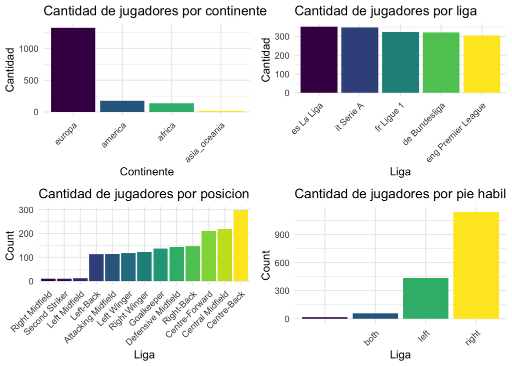

```r
colnames(df)[colnames(df) == "market_value_in_eur"] <- "precio"
df$continente <- factor(df$continente, levels = c("europa", "america", "africa", "asia_oceania"))
grafico1 <- ggplot(df, aes(x=continente, fill = continente)) +
  geom_bar() +
  scale_fill_viridis(discrete = TRUE, option = "D") + # Paleta accesible
  labs(y = "Cantidad",
       x = "Continente",
       title = "Cantidad de jugadores por continente") +
  theme_minimal() +
  theme(axis.text.x = element_text(angle=45, vjust=1, hjust=1),
        legend.position = "none")

df$Comp <- factor(df$Comp, levels = c("es La Liga", "it Serie A", "fr Ligue 1", "de Bundesliga",
                                      "eng Premier League"))
grafico2 <- ggplot(df, aes(x=Comp, fill = Comp)) +
  geom_bar() +
  scale_fill_viridis(discrete = TRUE, option = "D") + # Paleta accesible
  labs(y = "Cantidad", x = "Liga", title = "Cantidad de jugadores por liga") +
  theme_minimal() +
  theme(axis.text.x = element_text(angle=45, vjust=1, hjust=1),
        legend.position = "none")

posiciones <- table(df$sub_position)
posiciones <- names(sort(posiciones))
df$sub_position <- factor(df$sub_position, levels = posiciones)
grafico3 <- ggplot(df, aes(x=sub_position, fill = sub_position)) +
  geom_bar() +
  scale_fill_viridis(discrete = TRUE, option = "D") + # Paleta accesible
  labs(y = "Count", x = "Liga", title = "Cantidad de jugadores por posicion") +
  theme_minimal() +
  theme(axis.text.x = element_text(angle=45, vjust=1, hjust=1,),
        legend.position = "none")

grafico4 <- ggplot(df, aes(x=foot, fill = foot)) +
  geom_bar() +
  scale_fill_viridis(discrete = TRUE, option = "D") + # Paleta accesible
  labs(y = "Count", x = "Liga", title = "Cantidad de jugadores por pie habil") +
  theme_minimal() +
  theme(axis.text.x = element_text(angle=45, vjust=1, hjust=1,),
        legend.position = "none")

grid.arrange(grafico1, grafico2, grafico3, grafico4,nrow = 2)
```

### Jugadores por continente

Como era de esperarse, predominan los jugadores europeos. Los americanos y africanos están casi en igual medida, siendo un poco mayor los americanos. Asia y Oceanía en conjunto aportan solo una mínima cantidad.

### Cantidad de jugadores de liga

Todas las ligas están igual de representadas en el dataset, con lo cual el análisis del precio de jugadores según la liga será de interés.

### Jugadores por posición

Predominan los jugadores que se desempeñan en el centro del campo, como defensores centrales o mediocampistas centrales o mixtos. Esto tiene cierta lógica ya que 3 o 4 jugadores de campo siempre se desempeñan en estas posiciones. Llama la atención la alta proporción de centrodelanteros, ya que los equipos suelen usar un solo jugador en esa posición.

### Jugadores por pie hábil.

Como era de esperarse, mas de la mitad de los jugadores son derechos. Sin embargo, comparado con la proporción de personas diestras en el mundo (85%), la cantidad de jugadores zurdos es bastante mayor a estar proporción.

## Correlograma

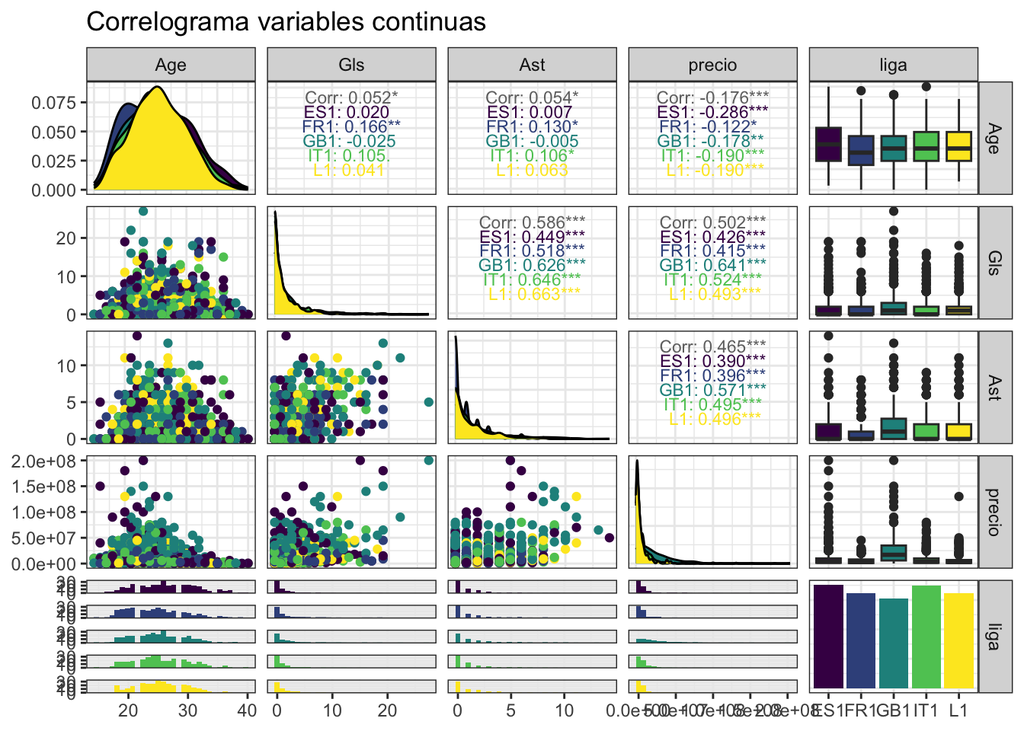

```r
df %>%
  dplyr::select(Age, Gls, Ast, precio) %>%
  mutate(liga = df$current_club_domestic_competition_id) %>%
  ggpairs(., mapping = aes(colour = liga),
          upper = list(continuous = wrap("cor", size = 3, hjust=0.5)), progress=FALSE) +
  scale_color_viridis_d(option = "D") +
  scale_fill_viridis_d(option = "D") +
  theme(axis.text.x = element_text(angle = 90, hjust = 1), legend.position = "bottom") +
  theme_bw() +
  labs(title='Correlograma variables continuas')
```

### Correlación entre Goles y Precio

Se observa una correlación positiva alta a moderada (Corr: 0.502). Esto sugiere que los jugadores que marcan más goles tienden a tener un valor de mercado más alto. La relación parece ser consistente a través de las diferentes ligas.

### Correlación entre Asistencias y Precio

Existe una correlación positiva moderada (Corr: 0.465). Indica que los jugadores que dan más asistencias también tienden a tener un mayor valor en el mercado. La correlación es algo menor que con los goles, sugiriendo que el mercado valora más la capacidad goleadora.

### Correlación entre Edad y Precio

Se observa una correlación negativa baja pero clara (Corr: -0.176). Sugiere que el valor de mercado tiende a disminuir con la edad del jugador. Esto tiene sentido desde una perspectiva de inversión, ya que los jugadores más jóvenes tienen mayor potencial de desarrollo y años de carrera por delante.

### Correlaciones cruzadas

Existe una correlación positiva moderada entre goles y asistencias (Corr: 0.586). Esto sugiere que los jugadores más efectivos tienden a destacar tanto en goles como en asistencias. La edad muestra correlaciones muy débiles con goles y asistencias.

## Jugadores mas caros

Los 10 jugadores mas caros

```r
mas_caros_nombre <- df %>%
  slice_max(order_by = precio, n=10)  %>%
  pull(name)
mas_caros_equipo <- df %>%
  slice_max(order_by = precio, n=10)  %>%
  pull(Squad)
mas_caros_precio <- df %>%
  slice_max(order_by = precio, n=10)  %>%
  pull(precio)
mas_caro <- data.frame(Nombre = mas_caros_nombre,
                       Equipo = mas_caros_equipo,
                       Precio = mas_caros_precio)

kable(mas_caro)
```

| Nombre | Equipo | Precio |
| --- | --- | --- |
| erling haaland | manchester city | 2.0e+08 |
| vinicius junior | real madrid | 2.0e+08 |
| jude bellingham | real madrid | 1.8e+08 |
| lamine yamal | barcelona | 1.5e+08 |
| phil foden | manchester city | 1.5e+08 |
| bukayo saka | arsenal | 1.4e+08 |
| federico valverde | real madrid | 1.3e+08 |
| florian wirtz | leverkusen | 1.3e+08 |
| rodri | manchester city | 1.3e+08 |
| declan rice | arsenal | 1.2e+08 |

## Jugadores mas baratos

```r
mas_baratos_nombre <- df %>%
  slice_min(order_by = precio, n=10)  %>%
  pull(name)
mas_baratos_equipo <- df %>%
  slice_min(order_by = precio, n=10)  %>%
  pull(Squad)
mas_baratos_precio <- df %>%
  slice_min(order_by = precio, n=10)  %>%
  pull(precio)
mas_barato <- data.frame(Nombre = mas_baratos_nombre,
                       Equipo = mas_baratos_equipo,
                       Precio = mas_baratos_precio)

kable(mas_barato)
```

| Nombre | Equipo | Precio |
| --- | --- | --- |
| aurelien pelon | lorient | 50000 |
| daouda traore | nice | 50000 |
| sofiane sidi ali | marseille | 50000 |
| steven baseya | strasbourg | 50000 |
| yassin tallal | getafe | 50000 |
| simone aresti | cagliari | 75000 |
| adel mahamoud | nantes | 100000 |
| antonio mirante | milan | 100000 |
| daniele sommariva | genoa | 100000 |
| dominic sadi | bournemouth | 100000 |
| francesco rossi | atalanta | 100000 |
| ichem ferrah | lille | 100000 |
| ivan cuellar | mallorca | 100000 |
| joel imasuen | werder bremen | 100000 |

# Regresión Lineal Simple

## Modelo “Goles son amores”

Precio = Goles

```r
modelo_clasico_goles = lm(data = train_data, formula = precio ~ Gls)
summary(modelo_clasico_goles)
```

```
##
## Call:
## lm(formula = precio ~ Gls, data = train_data)
##
## Residuals:
##       Min        1Q    Median        3Q       Max
## -58318585  -5505828  -3505828   2261548 112681415
##
## Coefficients:
##             Estimate Std. Error t value Pr(>|t|)
## (Intercept)  5238452     519499   10.08   <2e-16 ***
## Gls          3267375     147163   22.20   <2e-16 ***
## ---
## Signif. codes:  0 '***' 0.001 '**' 0.01 '*' 0.05 '.' 0.1 ' ' 1
##
## Residual standard error: 15400000 on 1155 degrees of freedom
## Multiple R-squared:  0.2991, Adjusted R-squared:  0.2985
## F-statistic: 492.9 on 1 and 1155 DF,  p-value: < 2.2e-16
```

Por cada gol anotado el precio del jugador aumenta en €3.267.375

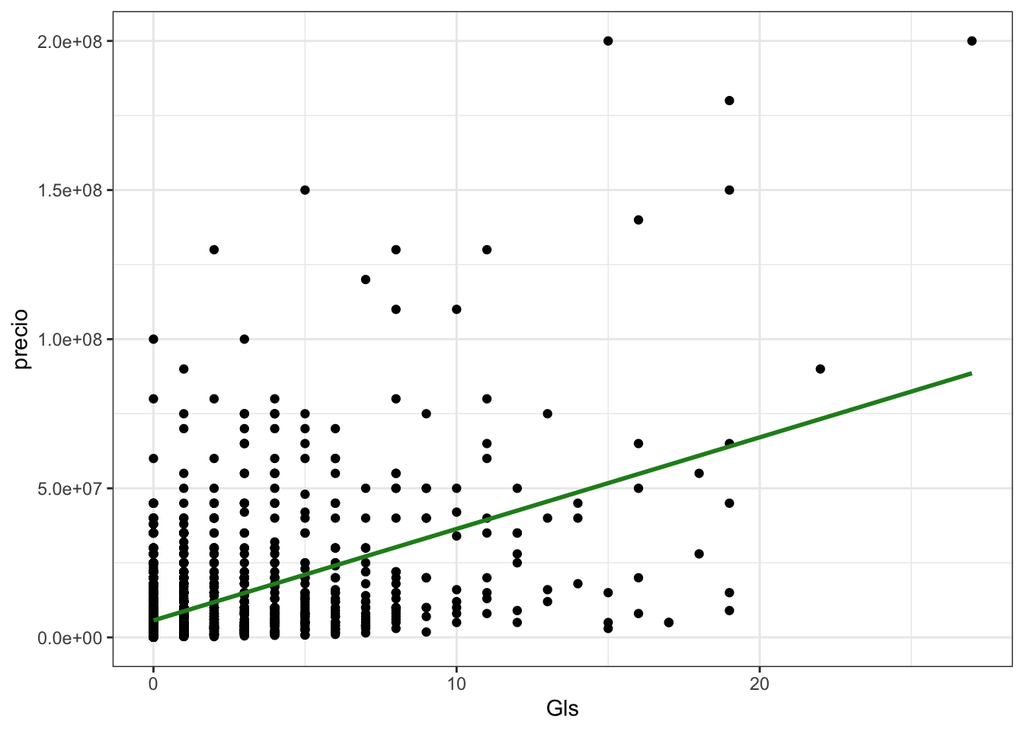

```r
ggplot(df, aes(x= Gls, y=precio))+
  geom_point() +
  theme_bw() +
  geom_smooth(method = "lm", formula = y ~ x, color="forestgreen", se = FALSE)
```

### Evaluación

#### Datos de entrenamiento

```r
pred_modelo_clasico_goles <- augment(modelo_clasico_goles, newdata = train_data)
cat("RMSE: ", rmse(data = pred_modelo_clasico_goles, truth = precio, estimate = .fitted)$.estimate)
```

```
## RMSE:  15388866
```

```r
cat("MAE: ", mae(data = pred_modelo_clasico_goles, truth = precio, estimate = .fitted)$.estimate)
```

```
## MAE:  9179813
```

#### Datos de prueba

```r
pred_modelo_clasico_goles <- augment(modelo_clasico_goles, newdata = test_data)
cat("RMSE: ", rmse(data = pred_modelo_clasico_goles, truth = precio, estimate = .fitted)$.estimate)
```

```
## RMSE:  17503869
```

```r
cat("MAE: ", mae(data = pred_modelo_clasico_goles, truth = precio, estimate = .fitted)$.estimate)
```

```
## MAE:  9732598
```

### Diagnóstico

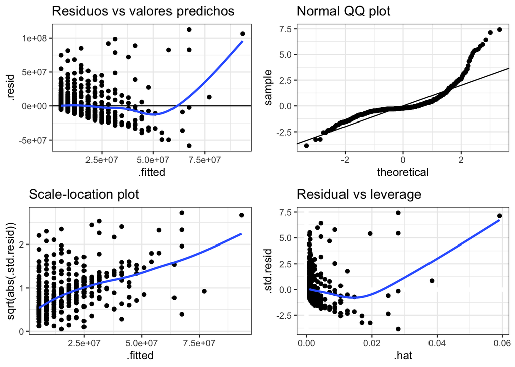

```r
datos_augmentados <- augment(modelo_clasico_goles)
g1 <- ggplot(datos_augmentados, aes(.fitted, .resid)) +
  geom_point() +
  geom_hline(yintercept = 0) +
  geom_smooth(se = FALSE) +
  labs(title = "Residuos vs valores predichos") +
  theme_bw()
g2 <- ggplot(datos_augmentados, aes(sample = .std.resid)) +
  stat_qq() +
  geom_abline() +
  labs(title = "Normal QQ plot") +
  theme_bw()
g3 <- ggplot(datos_augmentados, aes(.fitted, sqrt(abs(.std.resid)))) +
  geom_point() +
  geom_smooth(se = FALSE) +
  theme_bw() +
  labs(title = "Scale-location plot")
g4 <- ggplot(datos_augmentados, aes(.hat, .std.resid)) +
  geom_vline(size = 2, colour = "white", xintercept = 0) +
  geom_hline(size = 2, colour = "white", yintercept = 0) +
  geom_point() +
  geom_smooth(se = FALSE) +
  theme_bw() +
  labs(title = "Residual vs leverage")
grid.arrange(g1, g2, g3, g4, nrow=2)
```

#### Interpretación del Modelo

- El modelo establece una relación lineal simple entre el precio del jugador y los goles anotados
- Por cada gol anotado, el precio del jugador aumenta en €3,267,375
- El intercepto es €5,238,452, que representa el precio base estimado para un jugador sin goles
- El modelo es estadísticamente significativo (p-value < 2.2e-16)
- El R² ajustado es 0.2985, lo que indica que el modelo explica aproximadamente el 30% de la variabilidad en los precios

#### Evaluación del Rendimiento

- En datos de entrenamiento:
  - RMSE: 15,388,866
  - MAE: 9,179,813
- En datos de prueba:
  - RMSE: 17,503,869
  - MAE: 9,732,598
- La diferencia relativamente pequeña entre los errores de entrenamiento y prueba sugiere que el modelo no está sobreajustado

#### Diagnóstico de Residuos

- El gráfico de residuos vs valores predichos muestra un patrón de embudo, indicando heterocedasticidad
- El QQ-plot muestra desviaciones significativas de la normalidad, especialmente en las colas
- El Scale-location plot confirma la heterocedasticidad, con mayor variabilidad en los valores predichos más altos
- El gráfico de leverage muestra varios puntos con alta influencia que podrían estar afectando el modelo

#### Limitaciones del Modelo

- La relación lineal simple puede ser demasiado básica para capturar la complejidad del precio de los jugadores
- La presencia de heterocedasticidad sugiere que la variabilidad del precio aumenta con el número de goles
- El bajo R² indica que hay otros factores importantes que no están siendo considerados
- Los supuestos de normalidad y homocedasticidad no se cumplen adecuadamente

Este modelo, aunque estadísticamente significativo, tiene limitaciones importantes para predecir el precio de los jugadores. La violación de los supuestos básicos y el bajo poder explicativo sugieren que se necesita un modelo más complejo que incorpore variables adicionales y posiblemente transformaciones de las variables existentes.

## Modelo “La edad NO es lo de menos”

Precio = $Edad$ + $Edad^2$

```r
modelo_clasico_edad = modelo_clasico_edad2 = lm(data = train_data, formula = precio ~ Age + I(Age^2))
summary(modelo_clasico_edad)
```

```
##
## Call:
## lm(formula = precio ~ Age + I(Age^2), data = train_data)
##
## Residuals:
##       Min        1Q    Median        3Q       Max
## -13491197  -9734927  -5198104   2200547 186201791
##
## Coefficients:
##              Estimate Std. Error t value Pr(>|t|)
## (Intercept) -45547305   13549572  -3.362 0.000801 ***
## Age           5113615    1054307   4.850 1.40e-06 ***
## I(Age^2)      -110147      20094  -5.482 5.18e-08 ***
## ---
## Signif. codes:  0 '***' 0.001 '**' 0.01 '*' 0.05 '.' 0.1 ' ' 1
##
## Residual standard error: 17940000 on 1154 degrees of freedom
## Multiple R-squared:  0.05018,    Adjusted R-squared:  0.04853
## F-statistic: 30.48 on 2 and 1154 DF,  p-value: 1.255e-13
```

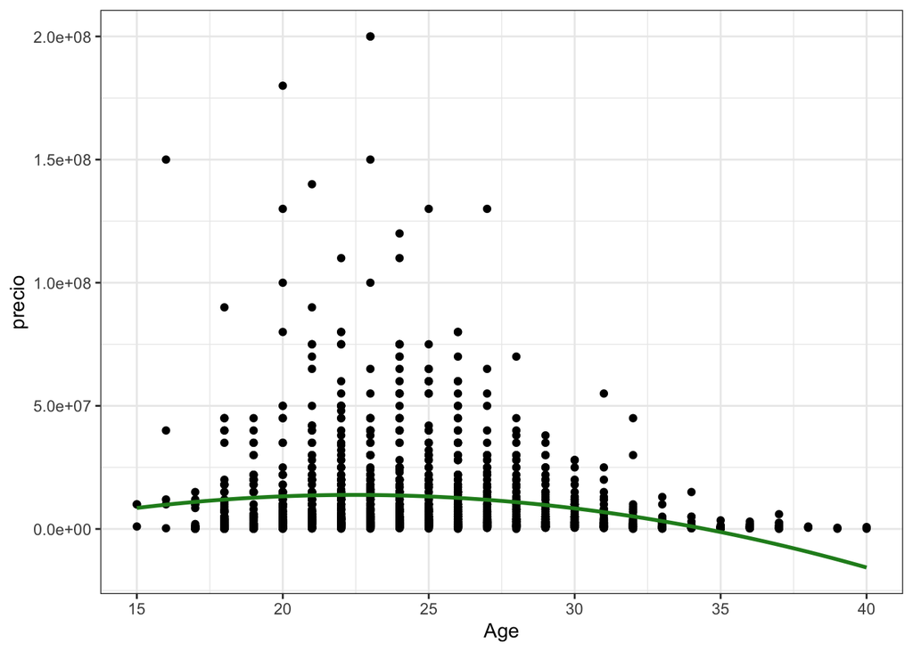

```r
ggplot(df, aes(x= Age, y=precio))+
  geom_point() +
  theme_bw() +
  geom_smooth(method = "lm", formula = y ~ x + I(x^2), color="forestgreen", se = FALSE)
```

```r
cat("A partir de los", round(5113615/(2*110147),0), "años, el precio de los jugadores comienza a disminuir")
```

```
## A partir de los 23 años, el precio de los jugadores comienza a disminuir
```

### Evaluación

#### Datos de entrenamiento

```r
pred_modelo_clasico_edad <- augment(modelo_clasico_edad, newdata = train_data)
cat("RMSE: ", rmse(data = pred_modelo_clasico_edad, truth = precio, estimate = .fitted)$.estimate)
```

```
## RMSE:  17914627
```

```r
cat("MAE: ", mae(data = pred_modelo_clasico_edad, truth = precio, estimate = .fitted)$.estimate)
```

```
## MAE:  10519126
```

#### Datos de prueba

```r
pred_modelo_clasico_edad <- augment(modelo_clasico_edad, newdata = test_data)
cat("RMSE: ", rmse(data = pred_modelo_clasico_edad, truth = precio, estimate = .fitted)$.estimate)
```

```
## RMSE:  18482683
```

```r
cat("MAE: ", mae(data = pred_modelo_clasico_edad, truth = precio, estimate = .fitted)$.estimate)
```

```
## MAE:  10655848
```

### Diagnóstico

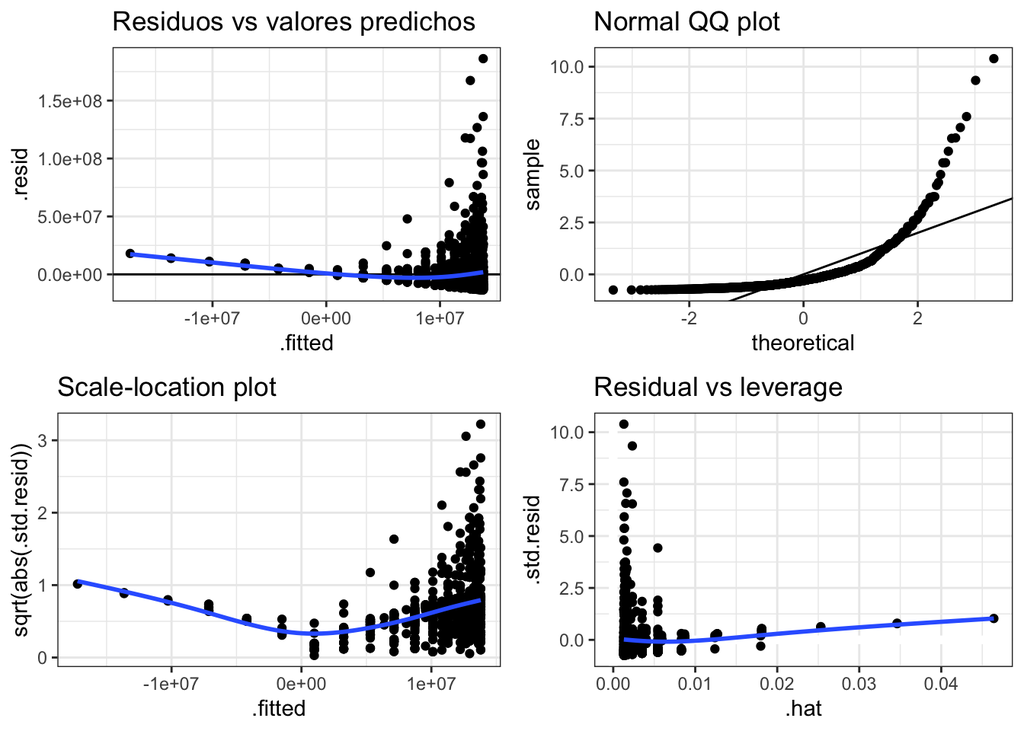

```r
datos_augmentados <- augment(modelo_clasico_edad)
g1 <- ggplot(datos_augmentados, aes(.fitted, .resid)) +
  geom_point() +
  geom_hline(yintercept = 0) +
  geom_smooth(se = FALSE) +
  labs(title = "Residuos vs valores predichos") +
  theme_bw()
g2 <- ggplot(datos_augmentados, aes(sample = .std.resid)) +
  stat_qq() +
  geom_abline() +
  labs(title = "Normal QQ plot") +
  theme_bw()
g3 <- ggplot(datos_augmentados, aes(.fitted, sqrt(abs(.std.resid)))) +
  geom_point() +
  geom_smooth(se = FALSE) +
  theme_bw() +
  labs(title = "Scale-location plot")
g4 <- ggplot(datos_augmentados, aes(.hat, .std.resid)) +
  geom_vline(size = 2, colour = "white", xintercept = 0) +
  geom_hline(size = 2, colour = "white", yintercept = 0) +
  geom_point() +
  geom_smooth(se = FALSE) +
  theme_bw() +
  labs(title = "Residual vs leverage")
grid.arrange(g1, g2, g3, g4, nrow=2)
```

#### Interpretación del Modelo

- El modelo establece una relación cuadrática entre el precio del jugador y su edad
- El precio aumenta con la edad hasta los 23 años, punto a partir del cual comienza a disminuir
- Los coeficientes son:
  - Edad: +5,113,615 (efecto lineal positivo)
  - Edad²: -110,147 (efecto cuadrático negativo)
  - Intercepto: -45,547,305
- El modelo es estadísticamente significativo (p-value: 1.255e-13)
- El R² ajustado es 0.04853, lo que indica que el modelo explica solo aproximadamente el 5% de la variabilidad en los precios

#### Evaluación del Rendimiento

- En datos de entrenamiento:
  - RMSE: 17,914,627
  - MAE: 10,519,126
- En datos de prueba:
  - RMSE: 18,482,683
  - MAE: 10,655,848
- Los errores son mayores que en el modelo de goles, sugiriendo que la edad por sí sola es un predictor más débil del precio

#### Diagnóstico de Residuos

- El gráfico de residuos vs valores predichos muestra un patrón de embudo similar al modelo anterior
- El QQ-plot muestra desviaciones significativas de la normalidad, especialmente en las colas superiores
- El Scale-location plot indica heterocedasticidad
- El gráfico de leverage muestra algunos puntos influyentes, aunque menos pronunciados que en el modelo de goles

#### Limitaciones del Modelo

- El muy bajo R² sugiere que la edad por sí sola no es un buen predictor del precio
- La relación cuadrática captura el hecho de que los jugadores alcanzan un pico de valor, pero el ajuste general es pobre
- Los supuestos de normalidad y homocedasticidad siguen sin cumplirse
- El modelo no captura otros factores importantes que afectan el precio

Este modelo confirma que existe una relación no lineal entre la edad y el precio de los jugadores, con un punto máximo alrededor de los 23 años. Sin embargo, su bajo poder explicativo sugiere que la edad debe combinarse con otras variables para obtener predicciones más precisas.

# Regresión Lineal Múltiple

## Modelo “Ahora va en serio”

$Precio$ = $Goles$ + $Edad$ + $Edad^2$ + $Asistencias$ + $Continente$ $de$ $nacimiento$ $del$ $jugador$ + $Liga$ $donde$ $juega$

```r
modelo_clasico_multiple_1 = lm(data = train_data,
                             formula = precio ~ Gls + Age + I(Age^2) + Ast +
                               continente + current_club_domestic_competition_id)
summary(modelo_clasico_multiple_1)
```

```
##
## Call:
## lm(formula = precio ~ Gls + Age + I(Age^2) + Ast + continente +
##     current_club_domestic_competition_id, data = train_data)
##
## Residuals:
##       Min        1Q    Median        3Q       Max
## -37702078  -5979937  -1352304   4179402 117568853
##
## Coefficients:
##                                         Estimate Std. Error t value Pr(>|t|)
## (Intercept)                             -8999579   10503367  -0.857 0.391719
## Gls                                      2189855     160682  13.629  < 2e-16
## Age                                      1607300     804050   1.999 0.045844
## I(Age^2)                                  -44966      15312  -2.937 0.003384
## Ast                                      2152607     244624   8.800  < 2e-16
## continenteamerica                        4494113    1848911   2.431 0.015223
## continenteasia_oceania                   2283362    3956794   0.577 0.564003
## continenteeuropa                         2748364    1459721   1.883 0.059981
## current_club_domestic_competition_idFR1 -4436917    1268565  -3.498 0.000487
## current_club_domestic_competition_idGB1 11060116    1286087   8.600  < 2e-16
## current_club_domestic_competition_idIT1 -2429060    1229943  -1.975 0.048515
## current_club_domestic_competition_idL1  -4011806    1265818  -3.169 0.001568
##
## (Intercept)
## Gls                                     ***
## Age                                     *
## I(Age^2)                                **
## Ast                                     ***
## continenteamerica                       *
## continenteasia_oceania
## continenteeuropa                        .
## current_club_domestic_competition_idFR1 ***
## current_club_domestic_competition_idGB1 ***
## current_club_domestic_competition_idIT1 *
## current_club_domestic_competition_idL1  **
## ---
## Signif. codes:  0 '***' 0.001 '**' 0.01 '*' 0.05 '.' 0.1 ' ' 1
##
## Residual standard error: 13350000 on 1145 degrees of freedom
## Multiple R-squared:  0.4783, Adjusted R-squared:  0.4733
## F-statistic: 95.43 on 11 and 1145 DF,  p-value: < 2.2e-16
```

### Evaluación

#### Datos de entrenamiento

```r
pred_modelo_clasico_multiple_1 <- augment(modelo_clasico_multiple_1, newdata = train_data)
cat("RMSE: ", rmse(data = pred_modelo_clasico_multiple_1, truth = precio, estimate = .fitted)$.estimate)
```

```
## RMSE:  13276913
```

```r
cat("MAE: ", mae(data = pred_modelo_clasico_multiple_1, truth = precio, estimate = .fitted)$.estimate)
```

```
## MAE:  8093280
```

#### Datos de prueba

```r
pred_modelo_clasico_multiple_1 <- augment(modelo_clasico_multiple_1, newdata = test_data)
cat("RMSE: ", rmse(data = pred_modelo_clasico_multiple_1, truth = precio, estimate = .fitted)$.estimate)
```

```
## RMSE:  15450180
```

```r
cat("MAE: ", mae(data = pred_modelo_clasico_multiple_1, truth = precio, estimate = .fitted)$.estimate)
```

```
## MAE:  8469906
```

### Diagnóstico

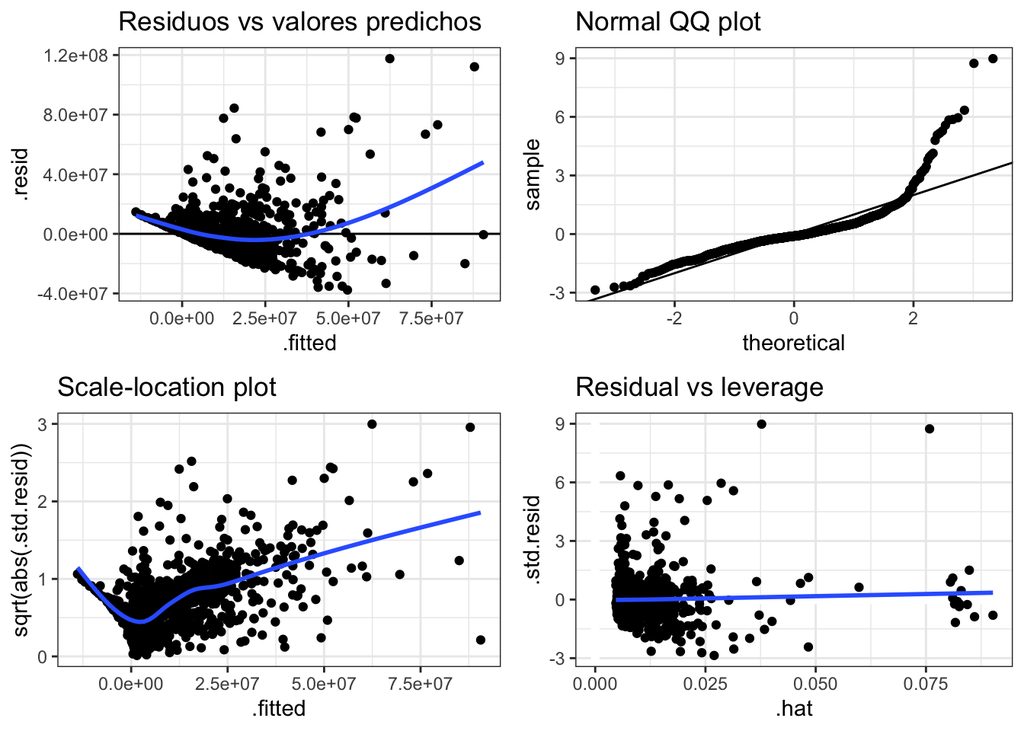

```r
datos_augmentados <- augment(modelo_clasico_multiple_1)
g5 <- ggplot(datos_augmentados, aes(.fitted, .resid)) +
  geom_point() +
  geom_hline(yintercept = 0) +
  geom_smooth(se = FALSE) +
  labs(title = "Residuos vs valores predichos") +
  theme_bw()
g6 <- ggplot(datos_augmentados, aes(sample = .std.resid)) +
  stat_qq() +
  geom_abline() +
  labs(title = "Normal QQ plot") +
  theme_bw()
g7 <- ggplot(datos_augmentados, aes(.fitted, sqrt(abs(.std.resid)))) +
  geom_point() +
  geom_smooth(se = FALSE) +
  theme_bw() +
  labs(title = "Scale-location plot")
g8 <- ggplot(datos_augmentados, aes(.hat, .std.resid)) +
  geom_vline(size = 2, colour = "white", xintercept = 0) +
  geom_hline(size = 2, colour = "white", yintercept = 0) +
  geom_point() +
  geom_smooth(se = FALSE) +
  theme_bw() +
  labs(title = "Residual vs leverage")
grid.arrange(g5, g6, g7, g8, nrow=2)
```

#### Evaluación del Rendimiento

- En datos de entrenamiento:
  - RMSE: 13,276,913
  - MAE: 8,093,280
- En datos de prueba:
  - RMSE: 15,450,180
  - MAE: 8,469,906
- La diferencia moderada entre errores de entrenamiento y prueba sugiere un nivel aceptable de generalización

#### Diagnóstico de Residuos

- El gráfico de residuos vs valores predichos muestra una mejora en el patrón de heterocedasticidad
- El QQ-plot indica una mejor aproximación a la normalidad en el centro de la distribución
- El Scale-location plot muestra una variabilidad más estable que los modelos anteriores
- El gráfico de leverage identifica menos puntos influyentes extremos

#### Mejoras Respecto a Modelos Anteriores

- El R² ajustado aumentó significativamente (de 0.30 y 0.05 a 0.47)
- Los errores de predicción (RMSE y MAE) disminuyeron
- Los diagnósticos de residuos muestran mejores propiedades estadísticas
- La incorporación de variables categóricas captura efectos específicos por continente y liga

Este modelo representa una mejora sustancial sobre los modelos simples anteriores, capturando efectos más complejos y reduciendo los errores de predicción. Sin embargo, aún hay espacio para mejoras, especialmente en el tratamiento de valores extremos y la posible incorporación de más variables relevantes.

## Modelo “Ahora va en serio 2”

$log(Precio)$ = $Goles$ + $Edad$ + $Edad^2$ + $Asistencias$ + $Continente$ $de$ $nacimiento$ $del$ $jugador$ + $Liga$ $donde$ $juega$

```r
modelo_clasico_multiple = lm(data = train_data,
                                formula = log(precio) ~ Gls + Age + I(Age^2) + Ast +
                                  continente + current_club_domestic_competition_id)
summary(modelo_clasico_multiple)
```

```
##
## Call:
## lm(formula = log(precio) ~ Gls + Age + I(Age^2) + Ast + continente +
##     current_club_domestic_competition_id, data = train_data)
##
## Residuals:
##     Min      1Q  Median      3Q     Max
## -4.0055 -0.6931  0.0515  0.7146  3.5105
##
## Coefficients:
##                                          Estimate Std. Error t value Pr(>|t|)
## (Intercept)                              5.573579   0.844203   6.602 6.19e-11
## Gls                                      0.116194   0.012915   8.997  < 2e-16
## Age                                      0.787591   0.064625  12.187  < 2e-16
## I(Age^2)                                -0.016285   0.001231 -13.232  < 2e-16
## Ast                                      0.172888   0.019662   8.793  < 2e-16
## continenteamerica                        0.404139   0.148605   2.720  0.00664
## continenteasia_oceania                   0.007232   0.318025   0.023  0.98186
## continenteeuropa                         0.041694   0.117324   0.355  0.72237
## current_club_domestic_competition_idFR1 -0.296188   0.101960  -2.905  0.00374
## current_club_domestic_competition_idGB1  0.817675   0.103369   7.910 6.02e-15
## current_club_domestic_competition_idIT1 -0.027229   0.098856  -0.275  0.78303
## current_club_domestic_competition_idL1  -0.285435   0.101740  -2.806  0.00511
##
## (Intercept)                             ***
## Gls                                     ***
## Age                                     ***
## I(Age^2)                                ***
## Ast                                     ***
## continenteamerica                       **
## continenteasia_oceania
## continenteeuropa
## current_club_domestic_competition_idFR1 **
## current_club_domestic_competition_idGB1 ***
## current_club_domestic_competition_idIT1
## current_club_domestic_competition_idL1  **
## ---
## Signif. codes:  0 '***' 0.001 '**' 0.01 '*' 0.05 '.' 0.1 ' ' 1
##
## Residual standard error: 1.073 on 1145 degrees of freedom
## Multiple R-squared:  0.467,  Adjusted R-squared:  0.4619
## F-statistic: 91.21 on 11 and 1145 DF,  p-value: < 2.2e-16
```

### Evaluación

#### Datos de entrenamiento

```r
pred_modelo_clasico_multiple <- augment(modelo_clasico_multiple, newdata = train_data)
pred_modelo_clasico_multiple$exp_fitted <- exp(pred_modelo_clasico_multiple$.fitted)
cat("RMSE: ", rmse(data = pred_modelo_clasico_multiple, truth = precio, estimate = exp_fitted)$.estimate)
```

```
## RMSE:  28500598
```

```r
cat("MAE: ", mae(data = pred_modelo_clasico_multiple, truth = precio, estimate = exp_fitted)$.estimate)
```

```
## MAE:  8057781
```

#### Datos de prueba

```r
pred_modelo_clasico_multiple <- augment(modelo_clasico_multiple, newdata = test_data)
pred_modelo_clasico_multiple$exp_fitted <- exp(pred_modelo_clasico_multiple$.fitted)
cat("RMSE: ", rmse(data = pred_modelo_clasico_multiple, truth = precio, estimate = exp_fitted)$.estimate)
```

```
## RMSE:  17508456
```

```r
cat("MAE: ", mae(data = pred_modelo_clasico_multiple, truth = precio, estimate = exp_fitted)$.estimate)
```

```
## MAE:  7357616
```

### Diagnóstico

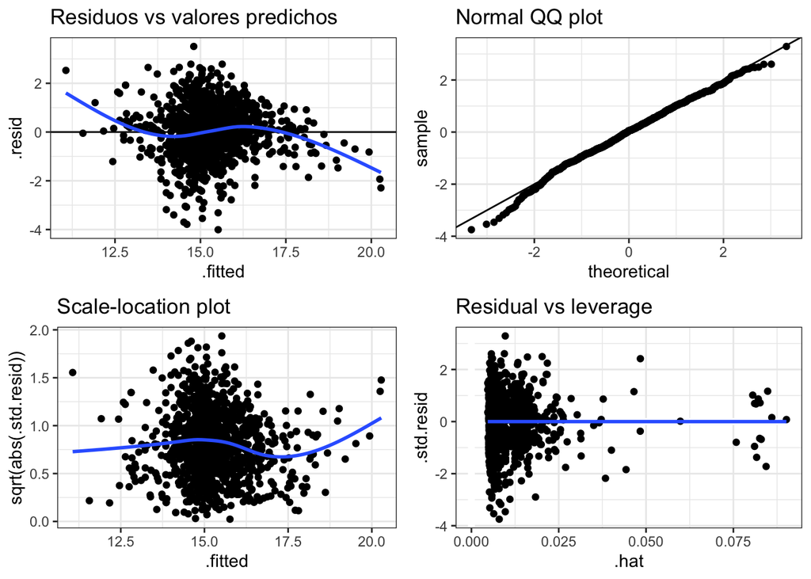

```r
datos_augmentados <- augment(modelo_clasico_multiple)
g9 <- ggplot(datos_augmentados, aes(.fitted, .resid)) +
  geom_point() +
  geom_hline(yintercept = 0) +
  geom_smooth(se = FALSE) +
  labs(title = "Residuos vs valores predichos") +
  theme_bw()
g10 <- ggplot(datos_augmentados, aes(sample = .std.resid)) +
  stat_qq() +
  geom_abline() +
  labs(title = "Normal QQ plot") +
  theme_bw()
g11 <- ggplot(datos_augmentados, aes(.fitted, sqrt(abs(.std.resid)))) +
  geom_point() +
  geom_smooth(se = FALSE) +
  theme_bw() +
  labs(title = "Scale-location plot")
g12 <- ggplot(datos_augmentados, aes(.hat, .std.resid)) +
  geom_vline(size = 2, colour = "white", xintercept = 0) +
  geom_hline(size = 2, colour = "white", yintercept = 0) +
  geom_point() +
  geom_smooth(se = FALSE) +
  theme_bw() +
  labs(title = "Residual vs leverage")
grid.arrange(g9, g10, g11, g12, nrow=2)
```

#### Evaluación del Rendimiento

- En datos de entrenamiento:
  - RMSE: 28,500,598
  - MAE: 8,057,781
- En datos de prueba:
  - RMSE: 17,508,456
  - MAE: 7,357,616
- La transformación logarítmica mejora el MAE en los datos de prueba, aunque el RMSE es más alto

#### Diagnóstico de Residuos

- El gráfico de residuos vs valores predichos muestra una distribución más homogénea
- El QQ-plot indica una notable mejora en la normalidad de los residuos
- El Scale-location plot muestra una varianza más estable
- El gráfico de leverage sugiere menos influencia de valores extremos

### Mejoras Respecto al Modelo Anterior

La transformación logarítmica del precio mejora las propiedades estadísticas del modelo y facilita la interpretación de los efectos. Este modelo parece más adecuado para predecir el precio de los jugadores, especialmente cuando se considera la interpretabilidad y la estabilidad de las predicciones.

# Regresión Lineal Múltiple Robusta

## Modelo “Goles son amores ROBUSTOS”

```r
modelo_lmrob_goles <- lmrob(formula = precio ~ Gls, data=train_data)
pred_modelo_lmrob_goles <- data.frame(
  Gls = train_data$Gls,
  precio_pred = predict(modelo_lmrob_goles, newdata = train_data)
)
summary(modelo_lmrob_goles)
```

```
##
## Call:
## lmrob(formula = precio ~ Gls, data = train_data)
##  \--> method = "MM"
## Residuals:
##       Min        1Q    Median        3Q       Max
## -11398849  -2040823    -40823   7178107 172914731
##
## Coefficients:
##             Estimate Std. Error t value Pr(>|t|)
## (Intercept)  3040823     233384   13.03  < 2e-16 ***
## Gls           890535     123689    7.20 1.08e-12 ***
## ---
## Signif. codes:  0 '***' 0.001 '**' 0.01 '*' 0.05 '.' 0.1 ' ' 1
##
## Robust residual standard error: 3632000
## Multiple R-squared:  0.2183, Adjusted R-squared:  0.2177
## Convergence in 23 IRWLS iterations
##
## Robustness weights:
##  158 observations c(3,19,23,52,55,58,67,76,80,83,89,92,105,112,130,132,141,143,144,156,161,163,164,167,172,173,175,178,190,200,204,212,216,218,226,232,248,253,256,262,265,271,283,287,288,289,290,292,301,309,310,316,319,321,322,327,333,338,339,341,354,366,367,368,372,384,385,388,390,407,433,461,46…
##   are outliers with |weight| <= 4.7e-05 ( < 8.6e-05);
##  44 weights are ~= 1. The remaining 955 ones are summarized as
##     Min.  1st Qu.   Median     Mean  3rd Qu.     Max.
## 0.002176 0.877400 0.959300 0.855000 0.983700 0.999000
## Algorithmic parameters:
##        tuning.chi                bb        tuning.psi        refine.tol
##         1.548e+00         5.000e-01         4.685e+00         1.000e-07
##           rel.tol         scale.tol         solve.tol          zero.tol
##         1.000e-07         1.000e-10         1.000e-07         1.000e-10
##       eps.outlier             eps.x warn.limit.reject warn.limit.meanrw
##         8.643e-05         4.911e-11         5.000e-01         5.000e-01
##      nResample         max.it       best.r.s       k.fast.s          k.max
##            500             50              2              1            200
##    maxit.scale      trace.lev            mts     compute.rd fast.s.large.n
##            200              0           1000              0           2000
##                   psi           subsampling                   cov
##            "bisquare"         "nonsingular"         ".vcov.avar1"
## compute.outlier.stats
##                  "SM"
## seed : int(0)
```

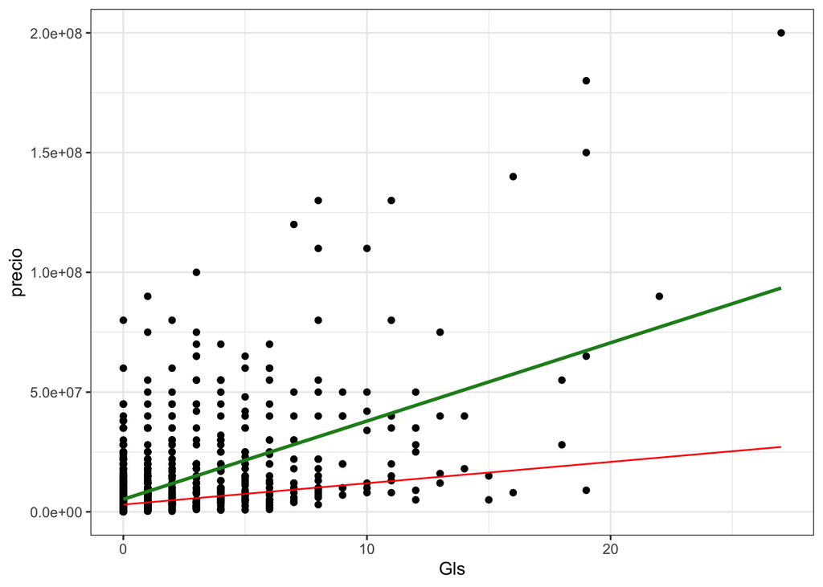

```r
ggplot(train_data, aes(x = Gls, y = precio)) +
  geom_point() +
  geom_smooth(method = "lm", formula = y ~ x, color="forestgreen", se = FALSE) +
  geom_line(data = pred_modelo_lmrob_goles, aes(x = Gls, y = precio_pred), color = "red") +
  theme_bw()
```

### Evaluación y comparación de contra modelos no robustos

```r
modelos_simples <- list(simple_1 = modelo_clasico_goles,
                simple_2 = modelo_lmrob_goles)

lista_predicciones_testing = map(.x = modelos_simples, .f = augment, newdata = test_data)


goles_clasico_test = lista_predicciones_testing$simple_1 %>%
  metrics(truth=precio, estimate=.fitted) %>%
  mutate(.estimate=round(.estimate, 4))

goles_robusto_test = lista_predicciones_testing$simple_2 %>%
  metrics(truth=precio, estimate=.fitted) %>%
  mutate(.estimate=round(.estimate, 4))


metrica_goles <- rbind(goles_clasico_test, goles_robusto_test)

modelitos_simples <- c(rep("Simple - Goles",3),rep("Robusto - Goles",3))
metricas <- cbind(modelitos_simples, metrica_goles)
kable(metricas)
```

| modelitos_simples | .metric | .estimator | .estimate |
| --- | --- | --- | --- |
| Simple - Goles | rmse | standard | 1.750387e+07 |
| Simple - Goles | rsq | standard | 1.559000e-01 |
| Simple - Goles | mae | standard | 9.732598e+06 |
| Robusto - Goles | rmse | standard | 1.914297e+07 |
| Robusto - Goles | rsq | standard | 1.559000e-01 |
| Robusto - Goles | mae | standard | 8.713804e+06 |

Disminuye el MAE (es mas que nada a modo ilustrativo y pedagógico, para que se vea sobre todo el gráfico anterior como se ajusta el modelo robusto a los datos despreciando los outliers)

## Primero Modelo Multiple Robusto

$log(Precio)$ = $Goles$ + $Edad$ + $Edad^2$ + $Asistencias$ + $Continente$ $de$ $nacimiento$ $del$ $jugador$ + $Liga$ $donde$ $juega$

```r
modelo_multiple_lmrob_2 <- lmrob(formula = log(precio) ~ Gls + Age + I(Age^2) + Ast +
                                 continente + current_club_domestic_competition_id,
                               data=train_data)
summary(modelo_multiple_lmrob_2)
```

```
##
## Call:
## lmrob(formula = log(precio) ~ Gls + Age + I(Age^2) + Ast + continente + current_club_domestic_competition_id,
##     data = train_data)
##  \--> method = "MM"
## Residuals:
##      Min       1Q   Median       3Q      Max
## -4.15651 -0.71534  0.01675  0.68707  3.45838
##
## Coefficients:
##                                          Estimate Std. Error t value Pr(>|t|)
## (Intercept)                              5.796426   1.235981   4.690 3.06e-06
## Gls                                      0.111085   0.010745  10.339  < 2e-16
## Age                                      0.772800   0.090728   8.518  < 2e-16
## I(Age^2)                                -0.016112   0.001655  -9.734  < 2e-16
## Ast                                      0.170219   0.014713  11.569  < 2e-16
## continenteamerica                        0.439570   0.130353   3.372 0.000771
## continenteasia_oceania                   0.065008   0.310255   0.210 0.834070
## continenteeuropa                         0.089042   0.106069   0.839 0.401378
## current_club_domestic_competition_idFR1 -0.231087   0.106080  -2.178 0.029578
## current_club_domestic_competition_idGB1  0.917136   0.110887   8.271 3.66e-16
## current_club_domestic_competition_idIT1 -0.014964   0.101669  -0.147 0.883015
## current_club_domestic_competition_idL1  -0.282461   0.098817  -2.858 0.004335
##
## (Intercept)                             ***
## Gls                                     ***
## Age                                     ***
## I(Age^2)                                ***
## Ast                                     ***
## continenteamerica                       ***
## continenteasia_oceania
## continenteeuropa
## current_club_domestic_competition_idFR1 *
## current_club_domestic_competition_idGB1 ***
## current_club_domestic_competition_idIT1
## current_club_domestic_competition_idL1  **
## ---
## Signif. codes:  0 '***' 0.001 '**' 0.01 '*' 0.05 '.' 0.1 ' ' 1
##
## Robust residual standard error: 1.024
```

[output cut: 8 more lines]

```
##        tuning.chi                bb        tuning.psi        refine.tol
##         1.548e+00         5.000e-01         4.685e+00         1.000e-07
##           rel.tol         scale.tol         solve.tol          zero.tol
##         1.000e-07         1.000e-10         1.000e-07         1.000e-10
##       eps.outlier             eps.x warn.limit.reject warn.limit.meanrw
##         8.643e-05         2.910e-09         5.000e-01         5.000e-01
##      nResample         max.it       best.r.s       k.fast.s          k.max
##            500             50              2              1            200
##    maxit.scale      trace.lev            mts     compute.rd fast.s.large.n
##            200              0           1000              0           2000
##                   psi           subsampling                   cov
##            "bisquare"         "nonsingular"         ".vcov.avar1"
## compute.outlier.stats
##                  "SM"
## seed : int(0)
```

### Diagnóstico

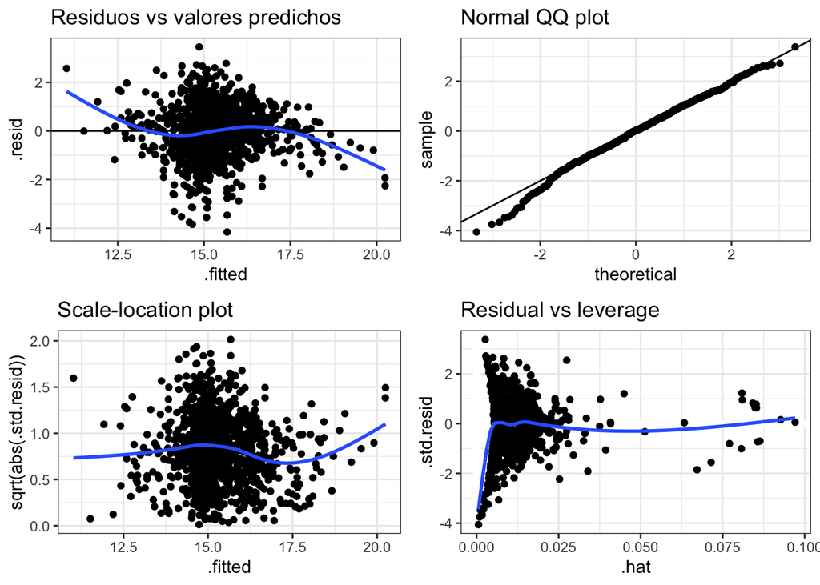

```r
#Diagnóstico
datos_augmentados <- augment(modelo_multiple_lmrob_2)
datos_augmentados$.std.resid <- datos_augmentados$.resid/(modelo_multiple_lmrob_2$scale*sqrt(1-hatvalues(modelo_multiple_lmrob_2)))
datos_augmentados$.hat <- hatvalues(modelo_multiple_lmrob_2)
g13 <- ggplot(datos_augmentados, aes(.fitted, .resid)) +
  geom_point() +
  geom_hline(yintercept = 0) +
  geom_smooth(se = FALSE) +
  labs(title = "Residuos vs valores predichos") +
  theme_bw()
g14 <- ggplot(datos_augmentados, aes(sample = .std.resid)) +
  stat_qq() +
  geom_abline() +
  labs(title = "Normal QQ plot") +
  theme_bw()
g15 <- ggplot(datos_augmentados, aes(.fitted, sqrt(abs(.std.resid)))) +
  geom_point() +
  geom_smooth(se = FALSE) +
  theme_bw() +
  labs(title = "Scale-location plot")
g16 <- ggplot(datos_augmentados, aes(.hat, .std.resid)) +
  geom_vline(size = 2, colour = "white", xintercept = 0) +
  geom_hline(size = 2, colour = "white", yintercept = 0) +
  geom_point() +
  geom_smooth(se = FALSE) +
  theme_bw() +
  labs(title = "Residual vs leverage")
grid.arrange(g13, g14, g15, g16, nrow = 2)
```

## Modelos Robustos con otras funciones psi

Se aplica la misma fórmula que el modelo anterior pero en lugar de usar la función $\psi$ por defecto bisqueare hacemos 5 modelos nuevos usando en cada uno diferentes $\psi$: lqq, welsh, optimal, hampel y ggw.

### Evaluación de todos los modelos

```r
modelo_multiple_lmrob_lqq <- lmrob(formula = log(precio) ~ Gls + Age + I(Age^2) + Ast +
                                   continente + current_club_domestic_competition_id,
                                 data=train_data,
                           psi = "lqq")

modelo_multiple_lmrob_welsh <- lmrob(formula = log(precio) ~ Gls + Age + I(Age^2) + Ast +
                                     continente + current_club_domestic_competition_id,
                                   data=train_data,
                                   psi = "welsh")

modelo_multiple_lmrob_optimal <- lmrob(formula = log(precio) ~ Gls + Age + I(Age^2) + Ast +
                                       continente + current_club_domestic_competition_id,
                                     data=train_data,
                                     psi = "optimal")


modelo_multiple_lmrob_hampel <- lmrob(formula = log(precio) ~ Gls + Age + I(Age^2) + Ast +
                                         continente + current_club_domestic_competition_id,
                                       data=train_data,
                                       psi = "hampel")

modelo_multiple_lmrob_ggw <- lmrob(formula = log(precio) ~ Gls + Age + I(Age^2) + Ast +
                                         continente + current_club_domestic_competition_id,
                                       data=train_data,
                                       psi = "ggw")


modelos <- list(multiple_1 = modelo_clasico_multiple_1,
                multiple_2 = modelo_clasico_multiple,
                robusto_2 = modelo_multiple_lmrob_2,
                robusto_3 = modelo_multiple_lmrob_lqq,
                robusto_4 = modelo_multiple_lmrob_welsh,
                robusto_5 = modelo_multiple_lmrob_optimal,
                robusto_6 = modelo_multiple_lmrob_hampel,
                robusto_7 = modelo_multiple_lmrob_ggw)

lista_predicciones_testing = map(.x = modelos, .f = augment, newdata = test_data)


metricas1_test = lista_predicciones_testing$multiple_1 %>%
  metrics(truth=precio, estimate=.fitted) %>%
  mutate(.estimate=round(.estimate, 4))

metricas2_test = lista_predicciones_testing$multiple_2 %>%
  mutate(exp_fitted= exp(.fitted)) %>%
  metrics(truth=precio, estimate=exp_fitted) %>%
  mutate(.estimate=round(.estimate, 4))

metricas3_test = lista_predicciones_testing$robusto_2 %>%
  mutate(exp_fitted= exp(.fitted)) %>%
  metrics(truth=precio, estimate=exp_fitted) %>%
  mutate(.estimate=round(.estimate, 4))

metricas4_test = lista_predicciones_testing$robusto_3 %>%
  mutate(exp_fitted= exp(.fitted)) %>%
  metrics(truth=precio, estimate=exp_fitted) %>%
  mutate(.estimate=round(.estimate, 4))

metricas5_test = lista_predicciones_testing$robusto_4 %>%
  mutate(exp_fitted= exp(.fitted)) %>%
  metrics(truth=precio, estimate=exp_fitted) %>%
  mutate(.estimate=round(.estimate, 4))

metricas6_test = lista_predicciones_testing$robusto_5 %>%
  mutate(exp_fitted= exp(.fitted)) %>%
  metrics(truth=precio, estimate=exp_fitted) %>%
  mutate(.estimate=round(.estimate, 4))

metricas7_test = lista_predicciones_testing$robusto_6 %>%
  mutate(exp_fitted= exp(.fitted)) %>%
  metrics(truth=precio, estimate=exp_fitted) %>%
  mutate(.estimate=round(.estimate, 4))

metricas8_test = lista_predicciones_testing$robusto_7 %>%
  mutate(exp_fitted= exp(.fitted)) %>%
  metrics(truth=precio, estimate=exp_fitted) %>%
  mutate(.estimate=round(.estimate, 4))



metricas <- rbind(metricas1_test, metricas2_test)
metricas <- rbind(metricas, metricas3_test)
metricas <- rbind(metricas, metricas4_test)
metricas <- rbind(metricas, metricas5_test)
metricas <- rbind(metricas, metricas6_test)
metricas <- rbind(metricas, metricas7_test)
metricas <- rbind(metricas, metricas8_test)

modelitos <- c(rep("Multiple - Precio",3),rep("Multiple - log(Precio)",3),
               rep("Robusto - log(Precio) - psi = bisqare",3),
               rep("Robusto - log(Precio) - psi = lqq",3),
               rep("Robusto - log(Precio) - psi = welsh",3),
               rep("Robusto - log(Precio) - psi = optimal",3),
               rep("Robusto - log(Precio) - psi = hampel",3),
               rep("Robusto - log(Precio) - psi = ggw",3))
metricas <- cbind(modelitos, metricas)
kable(metricas)
```

| modelitos | .metric | .estimator | .estimate |
| --- | --- | --- | --- |
| Multiple - Precio | rmse | standard | 1.545018e+07 |
| Multiple - Precio | rsq | standard | 3.343000e-01 |
| Multiple - Precio | mae | standard | 8.469906e+06 |
| Multiple - log(Precio) | rmse | standard | 1.750846e+07 |
| Multiple - log(Precio) | rsq | standard | 2.445000e-01 |
| Multiple - log(Precio) | mae | standard | 7.357616e+06 |
| Robusto - log(Precio) - psi = bisqare | rmse | standard | 1.759243e+07 |
| Robusto - log(Precio) - psi = bisqare | rsq | standard | 2.401000e-01 |
| Robusto - log(Precio) - psi = bisqare | mae | standard | 7.302473e+06 |
| Robusto - log(Precio) - psi = lqq | rmse | standard | 1.762257e+07 |
| Robusto - log(Precio) - psi = lqq | rsq | standard | 2.394000e-01 |
| Robusto - log(Precio) - psi = lqq | mae | standard | 7.311621e+06 |
| Robusto - log(Precio) - psi = welsh | rmse | standard | 1.760660e+07 |
| Robusto - log(Precio) - psi = welsh | rsq | standard | 2.399000e-01 |
| Robusto - log(Precio) - psi = welsh | mae | standard | 7.307849e+06 |
| Robusto - log(Precio) - psi = optimal | rmse | standard | 1.741595e+07 |
| Robusto - log(Precio) - psi = optimal | rsq | standard | 2.451000e-01 |
| Robusto - log(Precio) - psi = optimal | mae | standard | 7.276587e+06 |
| Robusto - log(Precio) - psi = hampel | rmse | standard | 1.767942e+07 |
| Robusto - log(Precio) - psi = hampel | rsq | standard | 2.383000e-01 |
| Robusto - log(Precio) - psi = hampel | mae | standard | 7.328352e+06 |
| Robusto - log(Precio) - psi = ggw | rmse | standard | 1.762931e+07 |
| Robusto - log(Precio) - psi = ggw | rsq | standard | 2.394000e-01 |
| Robusto - log(Precio) - psi = ggw | mae | standard | 7.313388e+06 |

En todos los robustos mejora el MAE, en el optimal es donde mas mejora.